# Pemodelan ARIMA - Pendugaan Parameter, Diagnostik Model, dan Peramalan

Jumlah Penumpang Harian Monorail (100 Periode)

Ferdian Hidayat

01 October 2026

# 1 Packages

```r
library(readxl)
library(ggplot2)
library(tseries)
library(MASS)
library(forecast)
library(TSA)
library(lmtest)
library(car)
library(knitr)
```

# 2 Data

Data yang digunakan adalah data jumlah penumpang harian Monorail sebanyak 100 periode, yaitu mulai 13 Februari 2024 sampai 22 Mei 2024.

```r
# File data diletakkan satu folder dengan Rmd ini di repositori GitHub
# (atau ganti dengan URL raw GitHub, seperti pada materi)
file.data <- "D:\\Kuliah\\Semester 5\\Metode Peramalan Deret Waktu\\mpdw\\Pertemuan 6 dan 7\\Tugas\\Data 100 Periode.xlsx"

data100 <- read_excel(file.data)
colnames(data100) <- c("date", "y")
data100$date <- as.Date(data100$date)
head(data100)
```

| date | y |
| --- | --- |
| 2024-02-13 | 56343 |
| 2024-02-14 | 56279 |
| 2024-02-15 | 55506 |
| 2024-02-16 | 55202 |
| 2024-02-17 | 43440 |
| 2024-02-18 | 40257 |

```r
cat("Periode:", format(min(data100$date)), "s.d.", format(max(data100$date)),
    "| Jumlah data:", nrow(data100), "| Data hilang:", sum(is.na(data100$y)))
```

```
## Periode: 2024-02-13 s.d. 2024-05-22 | Jumlah data: 100 | Data hilang: 0
```

Data dibagi menjadi data latih dan data uji dengan proporsi 80:20 (80 data latih dan 20 data uji). Karena data harian, pola mingguan diperhitungkan dengan `frequency = 7`.

```r
n.train <- 80
y.all   <- data100$y
train   <- y.all[1:n.train]
test    <- y.all[(n.train + 1):100]

train.ts <- ts(train, frequency = 7)
test.ts  <- ts(test,  start = n.train + 1)
```

## 2.1 Eksplorasi Data

### 2.1.1 Plot Data Penuh

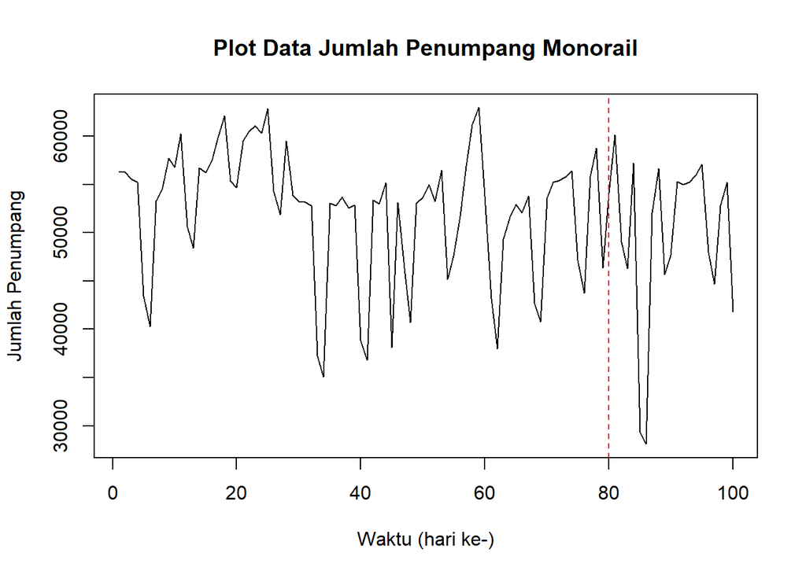

```r
plot.ts(ts(y.all), lty = 1, xlab = "Waktu (hari ke-)", ylab = "Jumlah Penumpang",
        main = "Plot Data Jumlah Penumpang Monorail")
abline(v = n.train, col = "red", lty = 2)
```

Garis merah putus-putus memisahkan data latih (kiri) dan data uji (kanan).

### 2.1.2 Plot Data Latih

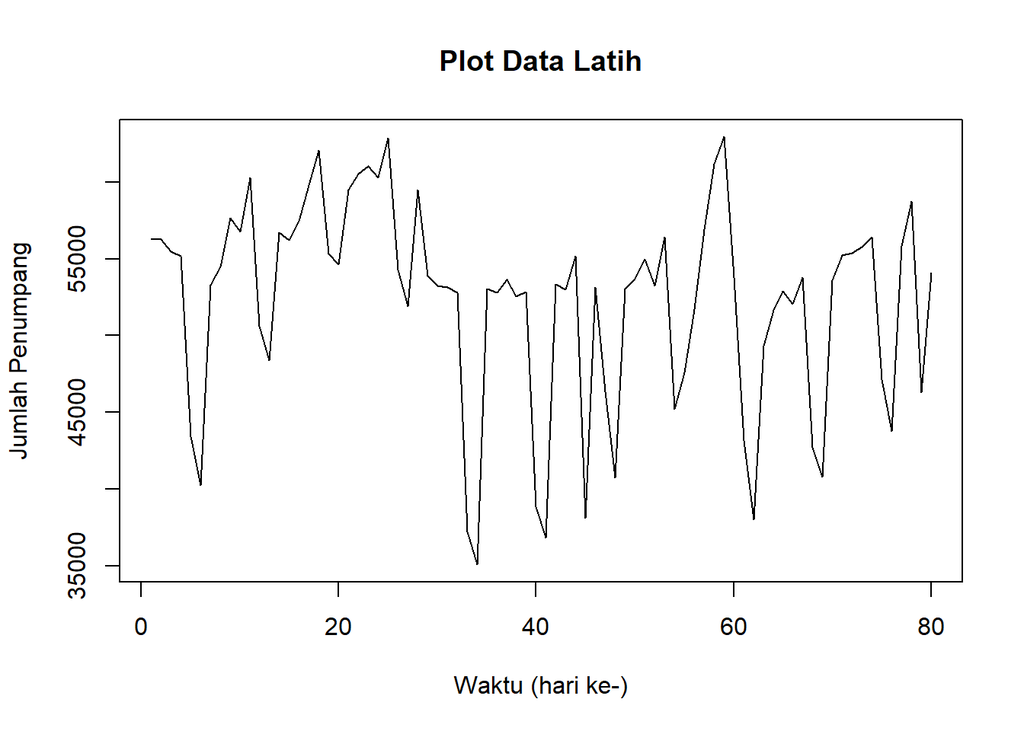

```r
plot.ts(ts(train), lty = 1, xlab = "Waktu (hari ke-)", ylab = "Jumlah Penumpang",
        main = "Plot Data Latih")
```

### 2.1.3 Plot Data Uji

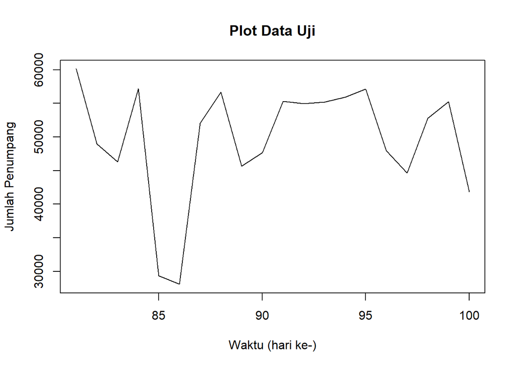

```r
plot.ts(test.ts, lty = 1, xlab = "Waktu (hari ke-)", ylab = "Jumlah Penumpang",
        main = "Plot Data Uji")
```

Pada plot terlihat pola yang berulang setiap 7 hari: jumlah penumpang pada hari kerja lebih tinggi (sekitar 52 ribu sampai 62 ribu) dibandingkan akhir pekan (sekitar 35 ribu sampai 50 ribu). Selain itu terdapat beberapa penurunan tajam yang tidak mengikuti pola mingguan, yaitu pada 28 Maret 2024 (sekitar 38 ribu, pada data latih), 7 dan 8 Mei 2024 (sekitar 29 ribu dan 28 ribu), serta 22 Mei 2024 (sekitar 42 ribu). Tiga tanggal terakhir berada pada data uji. Pola mingguan akan dicek melalui plot ACF, sedangkan penurunan tajam tersebut dicatat sebagai pencilan yang dapat memengaruhi pendugaan model (untuk pencilan pada data latih) dan akurasi peramalan (untuk pencilan pada data uji).

# 3 Uji Stasioneritas Data

## 3.1 Plot ACF

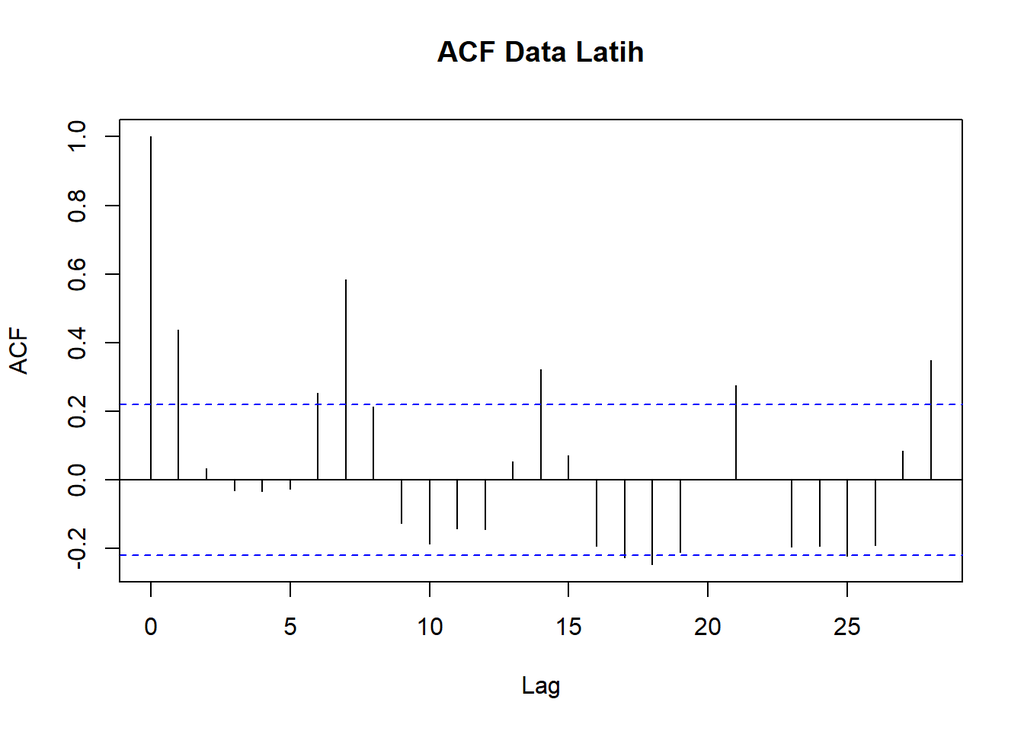

```r
stats::acf(train, lag.max = 28, main = "ACF Data Latih")
```

```r
acf.train <- stats::acf(train, lag.max = 28, plot = FALSE)$acf[-1]
lag.max.acf <- which.max(abs(acf.train))
```

Plot ACF menunjukkan autokorelasi yang kembali menguat pada lag kelipatan 7 (lag ke-7 sebesar 0,585 dan lag ke-14 sebesar 0,323), dengan autokorelasi terbesar berada pada lag ke-7 (0,585). Pola naik-turun yang berulang setiap 7 lag mengindikasikan bahwa data mengandung pola musiman mingguan sehingga data belum dapat dikatakan stasioner dalam rataan jika hanya dilihat secara eksplorasi.

## 3.2 Uji ADF

```r
adf.awal <- tseries::adf.test(train)
adf.awal
```

```
##
##  Augmented Dickey-Fuller Test
##
## data:  train
## Dickey-Fuller = -3.8931, Lag order = 4, p-value = 0.01886
## alternative hypothesis: stationary
```

$H_0$ : Data tidak stasioner dalam rataan

$H_1$ : Data stasioner dalam rataan

Berdasarkan uji ADF, didapat *p-value* sebesar 0,0189 yang lebih kecil dari taraf nyata 5% sehingga tolak $H_0$ dan data stasioner dalam rataan menurut uji ADF. Namun, plot ACF masih menunjukkan pola musiman sehingga pola tersebut tetap perlu ditangani pada tahap pemodelan. (Uji ADF menguji akar unit biasa, bukan akar unit musiman, sehingga uji ini tidak menggantikan pemeriksaan pola musiman pada plot ACF.)

## 3.3 Plot Box-Cox

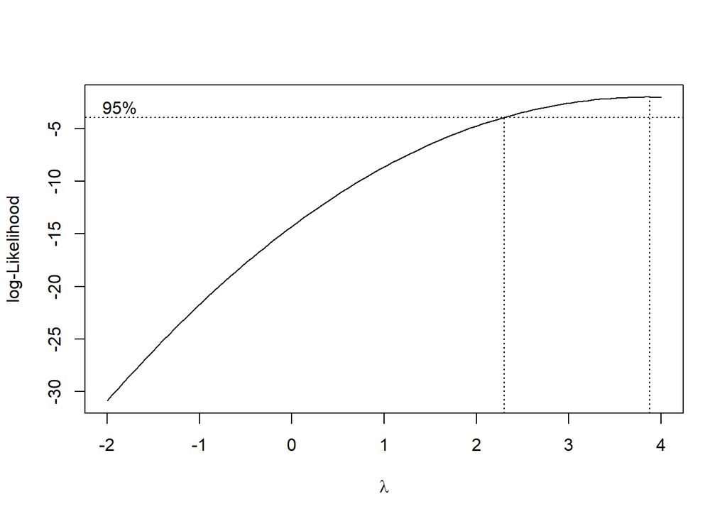

```r
index <- seq(1:n.train)
bc <- boxcox(train ~ index, lambda = seq(-2, 4, by = 0.1))
```

```r
lambda.opt <- bc$x[which.max(bc$y)]
ci <- bc$x[bc$y > max(bc$y) - 0.5 * qchisq(0.95, 1)]
c(Lambda_Optimum = lambda.opt, Batas_Bawah = min(ci), Batas_Atas = max(ci))
```

```
## Lambda_Optimum    Batas_Bawah     Batas_Atas
##       3.878788       2.303030       4.000000
```

Nilai $\lambda$ optimum sebesar 3,88 dengan selang kepercayaan 95% antara 2,30 dan 4,00. Selang tersebut tidak memuat nilai 1 sehingga data belum stasioner dalam ragam. Batas atas selang berimpit dengan batas atas rentang $\lambda$ yang dicoba (4), dan Box-Cox terhadap indeks waktu tidak memperhitungkan pola musiman maupun pencilan, sehingga hasil ini perlu ditafsirkan hati-hati. Pada tugas ini transformasi tidak dilakukan agar sejalan dengan materi, dan hal ini dicatat sebagai keterbatasan.

# 4 Penanganan Ketidakstasioneran Data

Karena terdapat pola mingguan, dilakukan differencing musiman lag 7 ($D = 1$). Dilanjutkan differencing biasa ($d = 1$) apabila data masih belum stasioner.

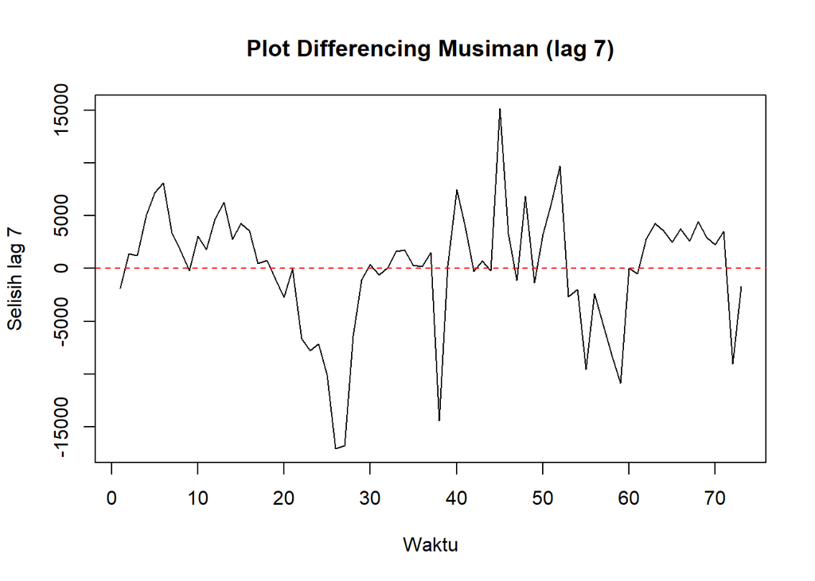

```r
# Differencing musiman lag 7
train.d7 <- diff(train, lag = 7)
plot.ts(train.d7, xlab = "Waktu", ylab = "Selisih lag 7",
        main = "Plot Differencing Musiman (lag 7)")
abline(h = mean(train.d7), col = "red", lty = 2)
```

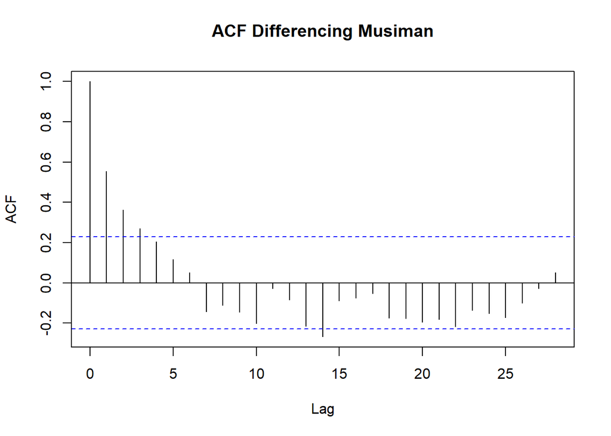

```r
stats::acf(train.d7,  lag.max = 28, main = "ACF Differencing Musiman")
```

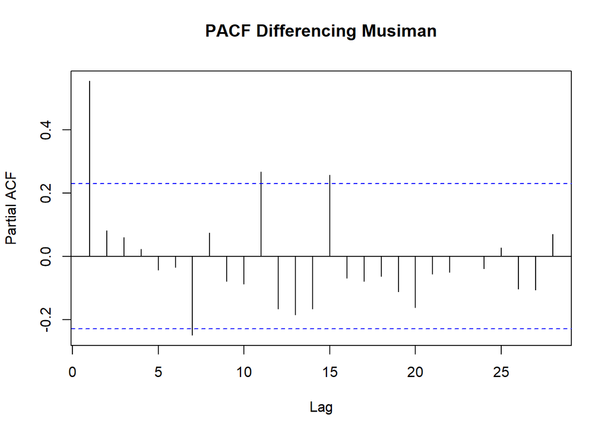

```r
stats::pacf(train.d7, lag.max = 28, main = "PACF Differencing Musiman")
```

```r
adf.d7 <- tseries::adf.test(train.d7)
adf.d7
```

```
##
##  Augmented Dickey-Fuller Test
##
## data:  train.d7
## Dickey-Fuller = -2.7202, Lag order = 4, p-value = 0.2819
## alternative hypothesis: stationary
```

Uji ADF setelah differencing musiman menghasilkan *p-value* 0,282 (> 0,05 sehingga data belum stasioner dalam rataan). Artinya differencing musiman saja belum cukup, sehingga perlu differencing biasa tambahan.

```r
# Differencing tambahan (d = 1)
train.d7d1 <- diff(train.d7, differences = 1)
adf.d7d1 <- tseries::adf.test(train.d7d1)
adf.d7d1
```

```
##
##  Augmented Dickey-Fuller Test
##
## data:  train.d7d1
## Dickey-Fuller = -4.7283, Lag order = 4, p-value = 0.01
## alternative hypothesis: stationary
```

Setelah differencing musiman dan differencing biasa, *p-value* uji ADF adalah 0,0100 (< 0,05) sehingga data sudah stasioner dalam rataan. Dengan demikian model tentatif yang dibandingkan menggunakan $d = 1$ dan $D = 1$. (Perlu dicatat bahwa setelah dua kali differencing hanya tersisa 72 pengamatan, dan uji ADF pada sampel sekecil ini memiliki daya yang terbatas. Kemungkinan *over-differencing* dibahas pada bagian model terbaik.)

Seperti pada materi, kestasioneran dalam ragam dicek kembali dengan Box-Cox pada data hasil differencing. Karena Box-Cox mensyaratkan nilai positif, data hasil differencing digeser terlebih dahulu dengan sebuah konstanta.

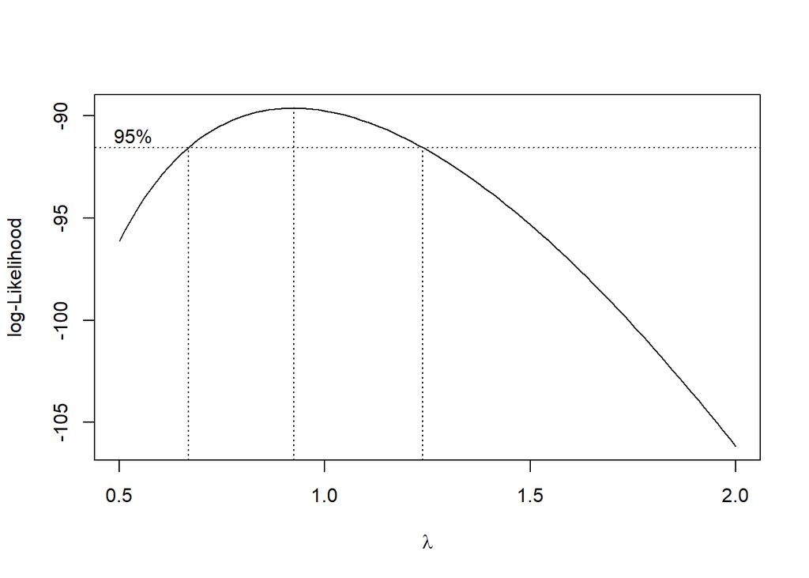

```r
index.diff <- seq(1:length(train.d7d1))

min.val <- min(train.d7d1)
if (min.val <= 0) {
  c.shift <- abs(min.val) + 1
  train.shifted <- train.d7d1 + c.shift
} else {
  train.shifted <- train.d7d1
}

bc.diff <- boxcox(train.shifted ~ index.diff, lambda = seq(0.5, 2, by = 0.1))
```

```r
lambda.opt.diff <- bc.diff$x[which.max(bc.diff$y)]
ci.diff <- bc.diff$x[bc.diff$y > max(bc.diff$y) - 0.5 * qchisq(0.95, df = 1)]
c(Lambda_Optimum = lambda.opt.diff, Batas_Bawah = min(ci.diff), Batas_Atas = max(ci.diff))
```

```
## Lambda_Optimum    Batas_Bawah     Batas_Atas
##      0.9242424      0.6818182      1.2272727
```

Nilai $\lambda$ optimum setelah differencing sebesar 0,92 dengan selang kepercayaan 95% antara 0,68 dan 1,23. Selang tersebut memuat nilai 1 sehingga data hasil differencing dianggap stasioner dalam ragam dan dapat dilanjutkan ke tahap identifikasi model. Karena data digeser dengan konstanta, nilai $\lambda$ ini bergantung pada konstanta yang dipilih sehingga hanya dipakai sebagai pemeriksaan kasar, sesuai prosedur pada materi.

# 5 Identifikasi Model

```r
acf.d   <- stats::acf(train.d7d1,  lag.max = 28, plot = FALSE)$acf[-1]
pacf.d  <- stats::pacf(train.d7d1, lag.max = 28, plot = FALSE)$acf
batas   <- 1.96 / sqrt(length(train.d7d1))
```

## 5.1 Plot ACF

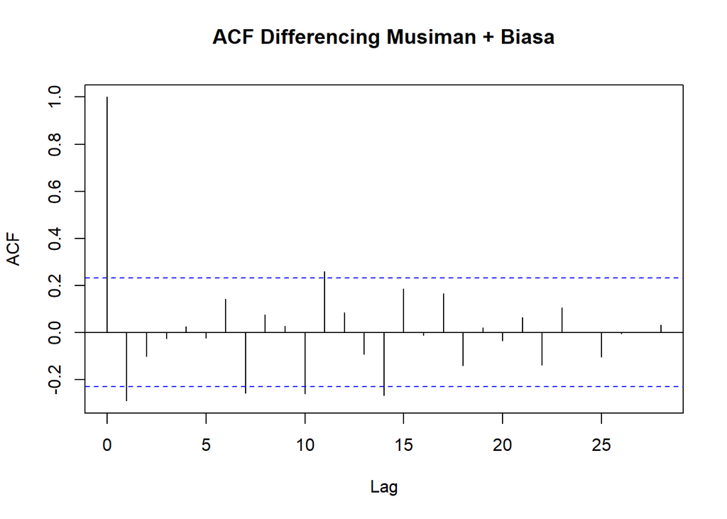

```r
stats::acf(train.d7d1, lag.max = 28, main = "ACF Differencing Musiman + Biasa")
```

Berdasarkan plot ACF data hasil differencing ($d = 1$, $D = 1$), spike signifikan terlihat pada lag ke-1 (-0,29) dan lag ke-7 (-0,26) dengan batas signifikansi sekitar $\pm$ 0,23. Spike pada lag ke-1 menunjukkan adanya komponen MA non-musiman ($q = 1$), sedangkan spike pada lag ke-7 menunjukkan komponen MA musiman ($Q = 1$). Spike kecil pada lag yang lebih jauh tidak diperhatikan karena nilainya hanya sedikit di atas batas. Jika PACF dianggap *tails off*, model tentatifnya adalah ARIMA(0,1,1)(0,1,1)[7].

## 5.2 Plot PACF

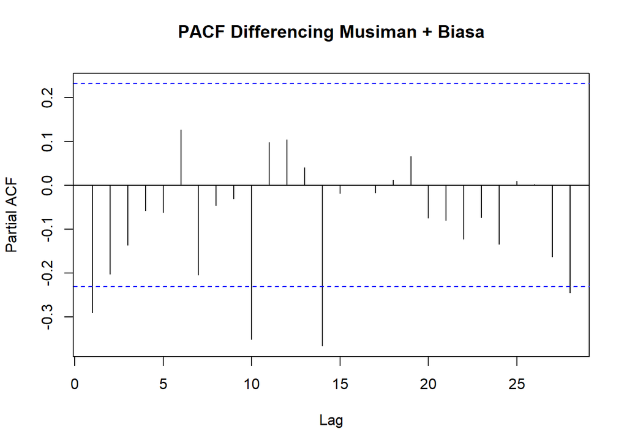

```r
stats::pacf(train.d7d1, lag.max = 28, main = "PACF Differencing Musiman + Biasa")
```

Berdasarkan plot PACF, spike signifikan terlihat pada lag ke-1 (-0,29), sedangkan lag berikutnya menurun secara perlahan (lag ke-2 sebesar -0,20 dan lag ke-3 sebesar -0,14). Jika plot ACF dianggap *tails off*, maka model tentatifnya adalah ARIMA(1,1,0)(0,1,1)[7]. Jika baik ACF maupun PACF dianggap *tails off*, model yang terbentuk adalah ARIMA(1,1,1)(0,1,1)[7].

## 5.3 Plot EACF

```r
eacf(train.d7d1)
```

```
## AR/MA
##   0 1 2 3 4 5 6 7 8 9 10 11 12 13
## 0 x o o o o o x o o x x  o  o  x
## 1 x o o o o o o o o o x  o  o  x
## 2 x o o o o o o o o o o  o  o  x
## 3 x x o o o o o o o o o  o  o  o
## 4 x o o o o o o o o o o  o  o  o
## 5 x o o o o o o o o o o  o  o  o
## 6 x o o o o x o o o o o  o  o  o
## 7 o o x o o o o o o o o  o  o  o
```

EACF dibaca dari ujung segitiga pola nol (o) untuk menentukan orde (p, q) non-musiman. Pada hasil di atas, kolom MA ke-0 masih berisi x pada baris AR 0 sampai 6 dan sisanya hampir seluruhnya berupa o, sehingga ujung segitiga tidak tegas dan mengarah ke orde kecil ($p, q \le 1$). EACF ini dihitung pada data yang masih memuat struktur musiman lag 7, sehingga EACF hanya dipakai sebagai penguat untuk model dengan orde non-musiman kecil, bukan sebagai penentu tunggal.

## 5.4 Model Tentatif

Berdasarkan ACF, PACF, dan EACF, ditetapkan model tentatif berikut (dengan $s = 7$). Model dengan $d = 0$ dan model ARIMA non-musiman disertakan sebagai pembanding saja, karena hasil uji ADF menunjukkan data memerlukan differencing musiman dan differencing biasa.

```r
kandidat <- list(
  "ARIMA(0,0,0)(0,1,1)[7]" = list(order = c(0,0,0), seasonal = c(0,1,1)),
  "ARIMA(1,0,0)(0,1,1)[7]" = list(order = c(1,0,0), seasonal = c(0,1,1)),
  "ARIMA(0,0,1)(0,1,1)[7]" = list(order = c(0,0,1), seasonal = c(0,1,1)),
  "ARIMA(1,0,1)(0,1,1)[7]" = list(order = c(1,0,1), seasonal = c(0,1,1)),
  "ARIMA(0,1,1)(0,1,1)[7]" = list(order = c(0,1,1), seasonal = c(0,1,1)),
  "ARIMA(1,1,0)(0,1,1)[7]" = list(order = c(1,1,0), seasonal = c(0,1,1)),
  "ARIMA(0,1,1)"           = list(order = c(0,1,1), seasonal = c(0,0,0))
)
kable(data.frame(No = seq_along(kandidat), Model = names(kandidat)))
```

| No | Model |
| --- | --- |
| 1 | ARIMA(0,0,0)(0,1,1)[7] |
| 2 | ARIMA(1,0,0)(0,1,1)[7] |
| 3 | ARIMA(0,0,1)(0,1,1)[7] |
| 4 | ARIMA(1,0,1)(0,1,1)[7] |
| 5 | ARIMA(0,1,1)(0,1,1)[7] |
| 6 | ARIMA(1,1,0)(0,1,1)[7] |
| 7 | ARIMA(0,1,1) |

# 6 Pendugaan Parameter Model Tentatif

```r
fit.model <- function(spec) {
  Arima(train.ts, order = spec$order,
        seasonal = list(order = spec$seasonal, period = 7), method = "ML")
}
models <- lapply(kandidat, fit.model)

for (nm in names(models)) {
  cat("\n=====", nm, "=====\n")
  print(summary(models[[nm]]))
  print(coeftest(models[[nm]]))
}
```

```
##
## ===== ARIMA(0,0,0)(0,1,1)[7] =====
## Series: train.ts
## ARIMA(0,0,0)(0,1,1)[7]
##
## Coefficients:
##          sma1
##       -0.8175
## s.e.   0.1609
##
## sigma^2 = 25896554:  log likelihood = -729.95
## AIC=1463.89   AICc=1464.06   BIC=1468.47
##
## Training set error measures:
##                     ME     RMSE     MAE       MPE     MAPE      MASE      ACF1
## Training set -735.1453 4827.722 3520.61 -2.320979 7.283125 0.8546194 0.6027012
##
## z test of coefficients:
##
##      Estimate Std. Error z value  Pr(>|z|)
## sma1 -0.81752    0.16089 -5.0811 3.752e-07 ***
## ---
## Signif. codes:  0 '***' 0.001 '**' 0.01 '*' 0.05 '.' 0.1 ' ' 1
##
##
## ===== ARIMA(1,0,0)(0,1,1)[7] =====
## Series: train.ts
## ARIMA(1,0,0)(0,1,1)[7]
##
## Coefficients:
##          ar1     sma1
##       0.6153  -1.0000
## s.e.  0.0918   0.2706
##
## sigma^2 = 14292882:  log likelihood = -712.64
## AIC=1431.29   AICc=1431.64   BIC=1438.16
##
## Training set error measures:
##                     ME     RMSE      MAE       MPE     MAPE      MASE
## Training set -363.0609 3561.591 2354.096 -1.249624 4.859609 0.5714508
```

[output cut: 124 more lines]

```
## s.e.   0.0980
##
## sigma^2 = 43320068:  log likelihood = -806.69
## AIC=1617.38   AICc=1617.54   BIC=1622.12
##
## Training set error measures:
##                     ME     RMSE      MAE       MPE     MAPE     MASE      ACF1
## Training set -194.7573 6499.005 5354.846 -2.040578 11.18827 1.299876 0.3072093
##
## z test of coefficients:
##
##      Estimate Std. Error z value  Pr(>|z|)
## ma1 -0.806702   0.097957 -8.2353 < 2.2e-16 ***
## ---
## Signif. codes:  0 '***' 0.001 '**' 0.01 '*' 0.05 '.' 0.1 ' ' 1
```

## 6.1 Ringkasan AIC

```r
signif.all <- function(m) {
  ct <- suppressWarnings(coeftest(m))
  p <- ct[, 4]
  p <- p[!grepl("drift|intercept", rownames(ct))]
  if (length(p) == 0) return(TRUE)
  all(!is.na(p) & p < 0.05)
}

arma.all <- sapply(models, function(m) m$arma)   # baris 6 = d, baris 7 = D
tabel.model <- data.frame(
  Model = names(models),
  d = arma.all[6, ],
  D = arma.all[7, ],
  AIC = sapply(models, AIC),
  BIC = sapply(models, BIC),
  Param.Signifikan = sapply(models, signif.all),
  row.names = NULL
)
tabel.model[order(tabel.model$AIC), ]
```

|  | Model | d | D | AIC | BIC | Param.Signifikan |
| --- | --- | --- | --- | --- | --- | --- |
| 5 | ARIMA(0,1,1)(0,1,1)[7] | 1 | 1 | 1415.833 | 1422.663 | TRUE |
| 6 | ARIMA(1,1,0)(0,1,1)[7] | 1 | 1 | 1420.115 | 1426.945 | TRUE |
| 4 | ARIMA(1,0,1)(0,1,1)[7] | 0 | 1 | 1430.726 | 1439.888 | FALSE |
| 2 | ARIMA(1,0,0)(0,1,1)[7] | 0 | 1 | 1431.289 | 1438.161 | TRUE |
| 3 | ARIMA(0,0,1)(0,1,1)[7] | 0 | 1 | 1443.365 | 1450.237 | TRUE |
| 1 | ARIMA(0,0,0)(0,1,1)[7] | 0 | 1 | 1463.893 | 1468.474 | TRUE |
| 7 | ARIMA(0,1,1) | 1 | 0 | 1617.384 | 1622.123 | TRUE |

```r
# AIC hanya sah dibandingkan antar model dengan orde differencing (d, D) yang sama,
# karena differencing mengubah data yang dimodelkan. Berdasarkan uji ADF dipakai d = 1 dan D = 1.
# Model terbaik: AIC terkecil di antara model (d = 1, D = 1) dengan seluruh parameter signifikan
pembanding <- tabel.model[tabel.model$d == 1 & tabel.model$D == 1, ]
layak <- pembanding[pembanding$Param.Signifikan, ]
if (nrow(layak) == 0) layak <- pembanding
nama.terbaik <- layak$Model[which.min(layak$AIC)]
model.terbaik <- models[[nama.terbaik]]
nama.terbaik
```

```
## [1] "ARIMA(0,1,1)(0,1,1)[7]"
```

Catatan: AIC hanya dibandingkan antar model dengan orde differencing yang sama ($d = 1$, $D = 1$). Model dengan $d$ atau $D$ berbeda memodelkan deret yang berbeda sehingga nilai AIC-nya tidak bisa diadu langsung; model tersebut ditampilkan hanya sebagai referensi.

Di antara model dengan $d = 1$ dan $D = 1$, AIC terkecil dimiliki oleh model **ARIMA(0,1,1)(0,1,1)[7]** (AIC = 1415,83) dan seluruh parameternya signifikan pada taraf nyata 5%. Model inilah yang dipilih untuk dianalisis lebih lanjut.

# 7 Analisis Sisaan

Model terbaik hasil identifikasi kemudian dicek asumsi sisaannya. Sisaan model ARIMA harus memenuhi asumsi normalitas, kebebasan sisaan, dan kehomogenan ragam, serta bernilai tengah nol. Diagnostik model dilakukan secara eksplorasi dan uji formal.

## 7.1 Eksplorasi Sisaan

```r
sisaan <- as.numeric(residuals(model.terbaik))

par(mfrow = c(2, 2))
car::qqPlot(sisaan, main = "Normal Q-Q Plot", ylab = "Sisaan")
```

```
## [1] 45 79
```

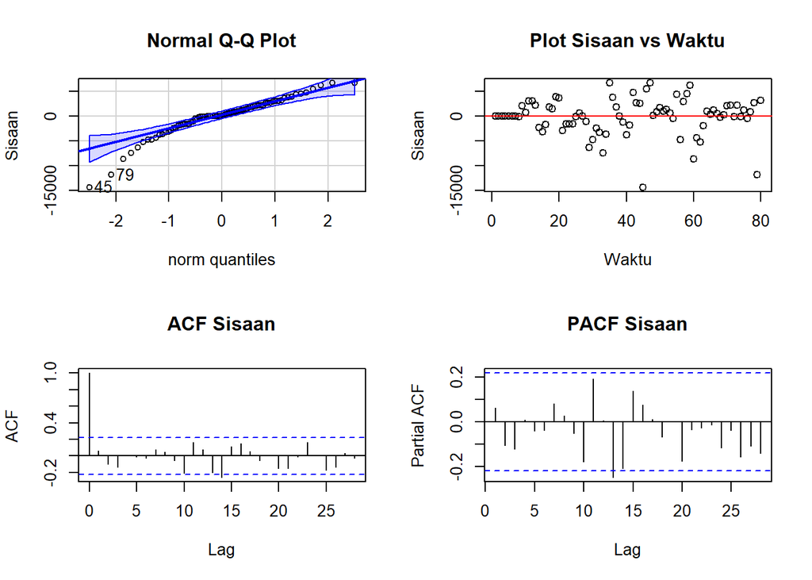

```r
plot(sisaan, type = "p", main = "Plot Sisaan vs Waktu", xlab = "Waktu", ylab = "Sisaan")
abline(h = 0, col = "red")
stats::acf(sisaan,  lag.max = 28, main = "ACF Sisaan")
stats::pacf(sisaan, lag.max = 28, main = "PACF Sisaan")
```

```r
par(mfrow = c(1, 1))
```

```r
batas.sis <- 1.96 / sqrt(length(sisaan))
k.acf  <- sum(abs(stats::acf(sisaan,  lag.max = 28, plot = FALSE)$acf[-1]) > batas.sis)
k.pacf <- sum(abs(stats::pacf(sisaan, lag.max = 28, plot = FALSE)$acf)     > batas.sis)
```

Pada plot kuantil-kuantil normal, sebagian besar titik mengikuti garis $45^{\circ}$, tetapi pengamatan ke-45 (28 Maret 2024) dan ke-79 (1 Mei 2024) ditandai sebagai titik yang paling menyimpang dari garis. Kedua titik ini berkaitan dengan pencilan yang telah dicatat pada tahap eksplorasi data. Pada plot sisaan terhadap waktu, sisaan menyebar di sekitar nol; lebar pita sisaan perlu dicermati terutama di sekitar pencilan tersebut. Pada plot ACF dan PACF sisaan, terdapat 1 lag (dari 28 lag pertama) pada ACF dan 1 lag pada PACF yang keluar dari batas signifikansi, sehingga secara eksploratif kebebasan sisaan perlu dikonfirmasi dengan uji formal.

## 7.2 Uji Formal

```r
# 1) Kenormalan
uji.ks <- ks.test(sisaan, "pnorm", mean(sisaan), sd(sisaan))
# 2) Kebebasan sisaan (autokorelasi), derajat bebas disesuaikan dengan banyak parameter
uji.lb <- Box.test(sisaan, lag = 10, type = "Ljung",
                   fitdf = length(coef(model.terbaik)))
# 3) Kehomogenan ragam
uji.arch <- Box.test(sisaan^2, lag = 10, type = "Ljung")
# 4) Nilai tengah sisaan sama dengan nol
uji.t <- t.test(sisaan, mu = 0, conf.level = 0.95)

hasil.diag <- data.frame(
  Asumsi = c("Normalitas (Kolmogorov-Smirnov)", "Kebebasan (Ljung-Box)",
             "Homogenitas ragam (Ljung-Box sisaan kuadrat)", "Nilai tengah = 0 (uji-t)"),
  p.value = c(uji.ks$p.value, uji.lb$p.value, uji.arch$p.value, uji.t$p.value)
)
hasil.diag$Keputusan <- ifelse(hasil.diag$p.value > 0.05,
                               "Asumsi terpenuhi", "Asumsi tidak terpenuhi")
hasil.diag
```

| Asumsi | p.value | Keputusan |
| --- | --- | --- |
| Normalitas (Kolmogorov-Smirnov) | 0.03799919 | Asumsi tidak terpenuhi |
| Kebebasan (Ljung-Box) | 0.45932590 | Asumsi terpenuhi |
| Homogenitas ragam (Ljung-Box sisaan kuadrat) | 0.73787570 | Asumsi terpenuhi |
| Nilai tengah = 0 (uji-t) | 0.90336874 | Asumsi terpenuhi |

**1) Kenormalan (Kolmogorov-Smirnov)**

$H_0$ : Sisaan menyebar normal

$H_1$ : Sisaan tidak menyebar normal

Didapat *p-value* sebesar 0,0380. Nilai ini lebih kecil dari taraf nyata 5% sehingga tolak $H_0$ dan sisaan **tidak menyebar normal**. Hal ini sejalan dengan plot kuantil-kuantil normal yang menunjukkan penyimpangan pada pengamatan pencilan. Dampaknya: titik ramalan umumnya tidak terlalu terpengaruh, tetapi selang prediksi yang dibentuk dengan asumsi normal kurang dapat diandalkan. (Uji KS dengan rataan dan simpangan baku yang diduga dari data bersifat konservatif, sehingga hasil ini sebaiknya dibaca bersama plot Q-Q.)

**2) Kebebasan sisaan (Ljung-Box, lag 10)**

$H_0$ : Sisaan saling bebas

$H_1$ : Sisaan tidak saling bebas

Didapat *p-value* sebesar 0,4593 yang lebih besar dari taraf nyata 5% sehingga gagal tolak $H_0$ dan sisaan saling bebas (tidak ada autokorelasi). Uji ini memakai 10 lag dan derajat bebas yang dikurangi banyaknya parameter model, sehingga lebih tepat dibanding pengujian pada satu lag saja.

**3) Kehomogenan ragam (Ljung-Box pada sisaan kuadrat)**

$H_0$ : Ragam sisaan homogen

$H_1$ : Ragam sisaan tidak homogen

Didapat *p-value* sebesar 0,7379 yang lebih besar dari taraf nyata 5% sehingga gagal tolak $H_0$ dan ragam sisaan homogen.

**4) Nilai tengah sisaan (uji-t)**

$H_0$ : Nilai tengah sisaan sama dengan 0

$H_1$ : Nilai tengah sisaan tidak sama dengan 0

Didapat *p-value* sebesar 0,9034 yang lebih besar dari taraf nyata 5% sehingga gagal tolak $H_0$ dan nilai tengah sisaan sama dengan nol.

**Kesimpulan diagnostik:** asumsi kebebasan sisaan, kehomogenan ragam, dan nilai tengah nol terpenuhi, sedangkan asumsi normalitas tidak terpenuhi. Pelanggaran normalitas kemungkinan besar disebabkan pencilan, bukan kesalahan spesifikasi struktur model, karena tidak ada autokorelasi sisa. Model tetap dapat digunakan untuk peramalan titik, dengan catatan pada selang prediksi.

# 8 Overfitting

Overfitting dilakukan dengan menaikkan orde AR ($p$) dan MA ($q$) non-musiman dari model terbaik untuk melihat apakah ada model yang lebih baik.

```r
o <- model.terbaik$arma          # (p, q, P, Q, s, d, D)
p0 <- o[1]; q0 <- o[2]; P0 <- o[3]; Q0 <- o[4]; d0 <- o[6]; D0 <- o[7]

fit.over <- function(p, q) {
  Arima(train.ts, order = c(p, d0, q),
        seasonal = list(order = c(P0, D0, Q0), period = 7), method = "ML")
}
over <- list(fit.over(p0 + 1, q0), fit.over(p0, q0 + 1))
names(over) <- c(sprintf("ARIMA(%d,%d,%d)(%d,%d,%d)[7]", p0 + 1, d0, q0, P0, D0, Q0),
                 sprintf("ARIMA(%d,%d,%d)(%d,%d,%d)[7]", p0, d0, q0 + 1, P0, D0, Q0))

for (nm in names(over)) {
  cat("\n=====", nm, "=====\n")
  print(coeftest(over[[nm]]))
}
```

```
##
## ===== ARIMA(1,1,1)(0,1,1)[7] =====
##
## z test of coefficients:
##
##      Estimate Std. Error z value  Pr(>|z|)
## ar1   0.27442    0.21236  1.2922    0.1963
## ma1  -0.71102    0.16248 -4.3759 1.209e-05 ***
## sma1 -0.99983    0.15880 -6.2962 3.051e-10 ***
## ---
## Signif. codes:  0 '***' 0.001 '**' 0.01 '*' 0.05 '.' 0.1 ' ' 1
##
##
## ===== ARIMA(0,1,2)(0,1,1)[7] =====
##
## z test of coefficients:
##
##      Estimate Std. Error z value  Pr(>|z|)
## ma1  -0.44056    0.11485 -3.8358 0.0001251 ***
## ma2  -0.13863    0.11504 -1.2050 0.2281904
## sma1 -0.99998    0.15849 -6.3095   2.8e-10 ***
## ---
## Signif. codes:  0 '***' 0.001 '**' 0.01 '*' 0.05 '.' 0.1 ' ' 1
```

```r
tabel.over <- data.frame(
  Model = c(nama.terbaik, names(over)),
  AIC = c(AIC(model.terbaik), sapply(over, AIC)),
  BIC = c(BIC(model.terbaik), sapply(over, BIC)),
  Param.Signifikan = c(signif.all(model.terbaik), sapply(over, signif.all)),
  row.names = NULL
)
tabel.over
```

| Model | AIC | BIC | Param.Signifikan |
| --- | --- | --- | --- |
| ARIMA(0,1,1)(0,1,1)[7] | 1415.833 | 1422.663 | TRUE |
| ARIMA(1,1,1)(0,1,1)[7] | 1416.296 | 1425.403 | FALSE |
| ARIMA(0,1,2)(0,1,1)[7] | 1416.399 | 1425.505 | FALSE |

```r
over.lebih.baik <- any(tabel.over$AIC[-1] < tabel.over$AIC[1] & tabel.over$Param.Signifikan[-1])
if (over.lebih.baik) {
  idx <- which.min(ifelse(tabel.over$Param.Signifikan, tabel.over$AIC, Inf))
  nama.final  <- tabel.over$Model[idx]
  model.final <- if (idx == 1) model.terbaik else over[[idx - 1]]
} else {
  nama.final  <- nama.terbaik
  model.final <- model.terbaik
}
nama.final
```

```
## [1] "ARIMA(0,1,1)(0,1,1)[7]"
```

Kedua model hasil *overfitting* (ARIMA(1,1,1)(0,1,1)[7] dan ARIMA(0,1,2)(0,1,1)[7]) memiliki AIC yang lebih besar (1416,30 dan 1416,40) dibandingkan model awal (1415,83), dan parameter tambahannya tidak signifikan. Oleh karena itu, model yang digunakan untuk peramalan adalah **ARIMA(0,1,1)(0,1,1)[7]**.

# 9 Model Terbaik

```r
summary(model.final)
```

```
## Series: train.ts
## ARIMA(0,1,1)(0,1,1)[7]
##
## Coefficients:
##           ma1     sma1
##       -0.4998  -1.0000
## s.e.   0.1234   0.1545
##
## sigma^2 = 15120996:  log likelihood = -704.92
## AIC=1415.83   AICc=1416.19   BIC=1422.66
##
## Training set error measures:
##                  ME     RMSE      MAE        MPE     MAPE      MASE       ACF1
## Training set -49.84 3637.426 2519.855 -0.5216348 5.095977 0.6116885 0.06156586
```

```r
coeftest(model.final)
```

```
##
## z test of coefficients:
##
##      Estimate Std. Error z value  Pr(>|z|)
## ma1  -0.49980    0.12342 -4.0496 5.129e-05 ***
## sma1 -1.00000    0.15451 -6.4721 9.667e-11 ***
## ---
## Signif. codes:  0 '***' 0.001 '**' 0.01 '*' 0.05 '.' 0.1 ' ' 1
```

```r
sma1.hat <- unname(coef(model.final)["sma1"])
sma1.se  <- unname(sqrt(diag(vcov(model.final)))["sma1"])
```

Model akhir adalah **ARIMA(0,1,1)(0,1,1)[7]** dengan koefisien MA non-musiman sebesar -0,4998 dan koefisien MA musiman sebesar -1,0000 (galat baku 0,1545).

**Catatan kritis.** Koefisien MA musiman berada tepat di batas keterbalikan (*invertibility*), yaitu $|\Theta_1| \approx 1$. Kondisi ini juga muncul pada hampir semua model tentatif bermusim. Ada dua konsekuensi: (1) uji-z untuk koefisien tersebut tidak sepenuhnya valid di batas parameter, sehingga tanda signifikansinya tidak boleh ditafsirkan berlebihan; dan (2) ini dapat menandakan *over-differencing* musiman, artinya pola mingguan mungkin lebih tepat dimodelkan sebagai musiman deterministik (bukan akar unit musiman). Hal ini ditindaklanjuti dengan model pembanding tanpa differencing musiman pada bagian Analisis Tambahan. Untuk keperluan tugas ini, model akhir tetap mengikuti prosedur pada materi.

# 10 Peramalan

Peramalan dilakukan dengan fungsi `forecast()` untuk 20 hari ke depan (sepanjang data uji). Karena differencing sudah termasuk dalam model pada fungsi `Arima()`, hasil ramalan langsung berada pada skala data asli (tidak perlu *inverse differencing* manual).

```r
h <- length(test)
ramalan <- forecast::forecast(model.final, h = h)
ramalan
```

```
##          Point Forecast    Lo 80    Hi 80    Lo 95    Hi 95
## 12.42857       54195.73 48990.48 59400.98 46234.99 62156.47
## 12.57143       43716.28 37896.23 49536.34 34815.28 52617.29
## 12.71429       41313.20 34937.35 47689.05 31562.18 51064.22
## 12.85714       52314.12 45427.18 59201.05 41781.46 62846.77
## 13.00000       53097.78 45735.71 60459.86 41838.47 64357.10
## 13.14286       53252.37 45446.51 61058.23 41314.34 65190.40
## 13.28571       52328.12 44102.38 60553.86 39747.94 64908.31
## 13.42857       53956.02 45189.92 62722.12 40549.42 67362.62
## 13.57143       43476.57 34270.45 52682.70 29397.02 57556.13
## 13.71429       41073.49 31447.44 50699.54 26351.71 55795.27
## 13.85714       52074.41 42045.99 62102.82 36737.27 67411.54
## 14.00000       52858.07 42438.56 63277.59 36922.80 68793.35
## 14.14286       53012.66 42226.87 63798.45 36517.21 69508.10
## 14.28571       52088.41 40948.38 63228.44 35051.21 69125.62
## 14.42857       53716.31 42118.51 65314.12 35979.00 71453.62
## 14.57143       43236.86 31255.75 55217.97 24913.34 61560.39
## 14.71429       40833.78 28481.26 53186.31 21942.22 59725.34
## 14.85714       51834.69 39121.60 64547.79 32391.69 71277.70
## 15.00000       52618.36 39547.51 65689.21 32628.22 72608.50
## 15.14286       52772.95 39369.60 66176.29 32274.30 73271.60
```

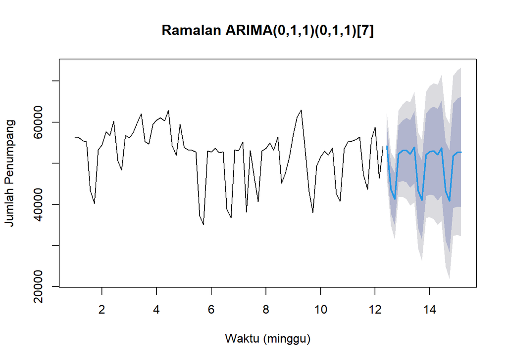

```r
plot(ramalan, xlab = "Waktu (minggu)", ylab = "Jumlah Penumpang",
     main = paste("Ramalan", nama.final))
```

Hasil ramalan mengikuti pola mingguan: nilai tinggi pada hari kerja (sekitar 52.800 penumpang) dan turun pada akhir pekan (sekitar 42.300 penumpang), dengan selang prediksi yang melebar seiring bertambahnya horizon. Pola ini sesuai dengan karakter data latih, tetapi ramalan tidak mampu mengantisipasi penurunan tajam yang tidak mengikuti pola mingguan.

## 10.1 Perbandingan Aktual vs Ramalan

```r
hasil.ramalan <- as.numeric(ramalan$mean)

perbandingan <- data.frame(
  Hari = (n.train + 1):100,
  Tanggal = data100$date[(n.train + 1):100],
  Aktual = test,
  Forecast = round(hasil.ramalan, 0),
  Galat = round(test - hasil.ramalan, 0)
)
perbandingan
```

| Hari | Tanggal | Aktual | Forecast | Galat |
| --- | --- | --- | --- | --- |
| 81 | 2024-05-03 | 60125 | 54196 | 5929 |
| 82 | 2024-05-04 | 49000 | 43716 | 5284 |
| 83 | 2024-05-05 | 46306 | 41313 | 4993 |
| 84 | 2024-05-06 | 57200 | 52314 | 4886 |
| 85 | 2024-05-07 | 29351 | 53098 | -23747 |
| 86 | 2024-05-08 | 28097 | 53252 | -25155 |
| 87 | 2024-05-09 | 52071 | 52328 | -257 |
| 88 | 2024-05-10 | 56660 | 53956 | 2704 |
| 89 | 2024-05-11 | 45689 | 43477 | 2212 |
| 90 | 2024-05-12 | 47674 | 41073 | 6601 |

[output cut: 10 more lines]

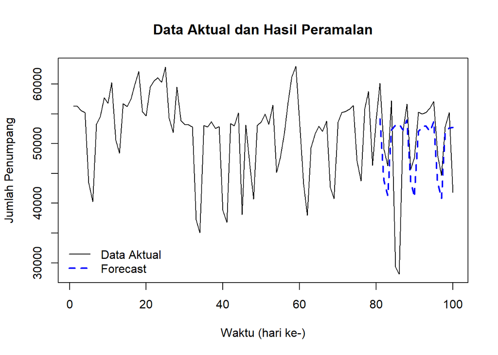

```r
plot(ts(y.all), type = "l", col = "black", xlab = "Waktu (hari ke-)",
     ylab = "Jumlah Penumpang", main = "Data Aktual dan Hasil Peramalan")
lines((n.train + 1):100, hasil.ramalan, col = "blue", lty = 2, lwd = 2)
legend("bottomleft", legend = c("Data Aktual", "Forecast"),
       col = c("black", "blue"), lty = c(1, 2), lwd = c(1, 2), bty = "n")
```

## 10.2 Akurasi

```r
akurasi <- accuracy(hasil.ramalan, test)
akurasi
```

```
##                 ME     RMSE      MAE       MPE     MAPE
## Test set -31.26038 8874.094 5979.762 -4.114317 15.59719
```

```r
# Analisis sensitivitas: akurasi tanpa pencilan pada data uji
pencilan.tgl <- as.Date(c("2024-05-07", "2024-05-08", "2024-05-22"))
idx.pencilan <- which(data100$date[(n.train + 1):100] %in% pencilan.tgl)
idx.bersih   <- setdiff(seq_along(test), idx.pencilan)

akurasi.bersih <- accuracy(hasil.ramalan[idx.bersih], test[idx.bersih])
galat <- test - hasil.ramalan

rbind("Semua data uji" = akurasi["Test set", c("ME","RMSE","MAE","MAPE")],
      "Tanpa pencilan" = akurasi.bersih["Test set", c("ME","RMSE","MAE","MAPE")])
```

```
##                        ME     RMSE      MAE     MAPE
## Semua data uji  -31.26038 8874.094 5979.762 15.59719
## Tanpa pencilan 3483.99377 3898.457 3514.244  6.78368
```

Pada seluruh data uji diperoleh RMSE sebesar 8.874, MAE sebesar 5.980, dan MAPE sebesar 15,60%. Nilai ini sangat dipengaruhi oleh penurunan tajam pada tanggal pencilan (7 dan 8 Mei 2024 dengan galat sekitar -24 ribu, serta 22 Mei 2024). Jika ketiga tanggal tersebut dikeluarkan, RMSE turun menjadi 3.898 dan MAPE menjadi 6,78%. Artinya model cukup baik menangkap pola mingguan pada hari-hari normal, dan penurunan akurasi terutama berasal dari kejadian luar pola yang tidak dapat diramalkan oleh model deret waktu univariat.

# 11 Analisis Tambahan: Model Musiman Tanpa Differencing Musiman

Bagian ini bersifat pembanding, bukan pengganti prosedur utama. Tujuannya menguji apakah pola mingguan lebih baik ditangkap dengan komponen AR musiman tanpa differencing musiman ($D = 0$), mengingat uji ADF awal menyatakan data stasioner dan koefisien MA musiman model utama berada di batas. Karena orde differencing berbeda, AIC tidak dibandingkan. Perbandingan dilakukan pada akurasi data uji, dengan catatan data uji hanya 20 pengamatan dan dipengaruhi pencilan, sehingga hasilnya tidak dipakai untuk mengganti model utama secara otomatis.

```r
alt.spec <- list(
  "ARIMA(1,0,0)(1,0,0)[7]" = list(order = c(1,0,0), seasonal = c(1,0,0)),
  "ARIMA(1,0,1)(1,0,0)[7]" = list(order = c(1,0,1), seasonal = c(1,0,0)),
  "ARIMA(1,0,0)(1,0,1)[7]" = list(order = c(1,0,0), seasonal = c(1,0,1))
)
alt.models <- lapply(alt.spec, function(s)
  tryCatch(Arima(train.ts, order = s$order,
                 seasonal = list(order = s$seasonal, period = 7), method = "ML"),
           error = function(e) NULL))
alt.models <- Filter(Negate(is.null), alt.models)

for (nm in names(alt.models)) {
  cat("\n=====", nm, "=====\n")
  print(coeftest(alt.models[[nm]]))
}
```

```
##
## ===== ARIMA(1,0,0)(1,0,0)[7] =====
##
## z test of coefficients:
##
##             Estimate Std. Error z value  Pr(>|z|)
## ar1       5.0997e-01 9.5249e-02  5.3541 8.598e-08 ***
## sar1      6.7807e-01 8.1385e-02  8.3316 < 2.2e-16 ***
## intercept 5.2180e+04 2.6335e+03 19.8139 < 2.2e-16 ***
## ---
## Signif. codes:  0 '***' 0.001 '**' 0.01 '*' 0.05 '.' 0.1 ' ' 1
##
##
## ===== ARIMA(1,0,1)(1,0,0)[7] =====
##
## z test of coefficients:
##
##              Estimate  Std. Error z value  Pr(>|z|)
## ar1        5.1661e-01  2.1882e-01  2.3609   0.01823 *
## ma1       -8.9519e-03  2.6670e-01 -0.0336   0.97322
## sar1       6.7891e-01  8.5065e-02  7.9812  1.45e-15 ***
## intercept  5.2164e+04  2.6516e+03 19.6727 < 2.2e-16 ***
## ---
## Signif. codes:  0 '***' 0.001 '**' 0.01 '*' 0.05 '.' 0.1 ' ' 1
##
##
## ===== ARIMA(1,0,0)(1,0,1)[7] =====
##
## z test of coefficients:
##
##              Estimate  Std. Error  z value  Pr(>|z|)
## ar1        5.9251e-01  8.9131e-02   6.6476 2.980e-11 ***
## sar1       9.9833e-01  8.6737e-03 115.0983 < 2.2e-16 ***
## sma1      -9.2816e-01  1.8113e-01  -5.1242 2.988e-07 ***
## intercept  5.2144e+04  4.5389e+03  11.4883 < 2.2e-16 ***
## ---
## Signif. codes:  0 '***' 0.001 '**' 0.01 '*' 0.05 '.' 0.1 ' ' 1
```

```r
alt.pred  <- lapply(alt.models, function(m) as.numeric(forecast::forecast(m, h = h)$mean))
semua.pred <- c(setNames(list(hasil.ramalan), nama.final), alt.pred)

ambil <- function(pred, idx = seq_along(test)) {
  accuracy(pred[idx], test[idx])["Test set", c("RMSE", "MAE", "MAPE")]
}
a1 <- t(sapply(semua.pred, ambil))
a2 <- t(sapply(semua.pred, ambil, idx = idx.bersih))

# Kriteria kelayakan pembanding: seluruh parameter signifikan dan koefisien AR musiman
# tidak mendekati 1 (|sar| < 0,95), agar tidak terjadi akar unit musiman yang tersamar
layak.alt <- sapply(alt.models, function(m) {
  cf  <- coef(m)
  sar <- cf[grepl("^sar", names(cf))]
  signif.all(m) && all(abs(sar) < 0.95)
})

tabel.alt <- data.frame(
  Model = names(semua.pred),
  RMSE.semua   = a1[, "RMSE"], MAPE.semua   = a1[, "MAPE"],
  RMSE.tanpa.pencilan = a2[, "RMSE"], MAPE.tanpa.pencilan = a2[, "MAPE"],
  Layak = c(NA, unname(layak.alt)),
  row.names = NULL
)
tabel.alt
```

| Model | RMSE.semua | MAPE.semua | RMSE.tanpa.pencilan | MAPE.tanpa.pencilan | Layak |
| --- | --- | --- | --- | --- | --- |
| ARIMA(0,1,1)(0,1,1)[7] | 8874.094 | 15.59719 | 3898.457 | 6.783680 | NA |
| ARIMA(1,0,0)(1,0,0)[7] | 8282.030 | 13.05621 | 2976.895 | 4.484099 | TRUE |
| ARIMA(1,0,1)(1,0,0)[7] | 8280.184 | 13.05004 | 2980.515 | 4.482649 | FALSE |
| ARIMA(1,0,0)(1,0,1)[7] | 9054.378 | 13.50126 | 2105.048 | 3.220960 | FALSE |

Model pembanding dinilai layak jika seluruh parameternya signifikan dan koefisien AR musimannya tidak mendekati 1. Syarat kedua penting: pada model dengan AR musiman mendekati 1 dan MA musiman negatif besar, kedua komponen saling meniadakan sehingga model hampir setara dengan differencing musiman, dan hasilnya rapuh. Kolom `Layak` pada tabel di atas menunjukkan hasil pemeriksaan ini.

```r
kand <- which(tabel.alt$Layak %in% TRUE)
ada.alt <- length(kand) > 0
if (ada.alt) {
  ia <- kand[which.min(tabel.alt$RMSE.semua[kand])]
  nama.alt <- tabel.alt$Model[ia]
  lebih.baik <- tabel.alt$RMSE.semua[ia] < tabel.alt$RMSE.semua[1] &&
                tabel.alt$RMSE.tanpa.pencilan[ia] < tabel.alt$RMSE.tanpa.pencilan[1]
}
rb <- function(x) format(round(x), big.mark = ".", decimal.mark = ",")
```

Model pembanding layak dengan RMSE terkecil pada seluruh data uji adalah ARIMA(1,0,0)(1,0,0)[7]. RMSE-nya 8.282 (semua data uji) dan 2.977 (tanpa pencilan), dibandingkan model utama ARIMA(0,1,1)(0,1,1)[7] sebesar 8.874 dan 3.898. Model pembanding ini lebih akurat pada kedua ukuran, sehingga pemodelan musiman tanpa differencing musiman layak dipertimbangkan sebagai model alternatif.